# City crime data summary

The data for Louisville included in the Crime Open Database (CODE) includes records for 1,054,779 offences between 2009 and 2017.

# Excluded cases

Cases are excluded from the final dataset for various reasons. Overall 556,369 (53% of the total) cases have been excluded.

| Reason | Cases |
| --- | --- |
| Total | 1,054,779 |
| Incomplete co-ordinates | 55,053 |
| Location outside city | 436,849 |
| Non-criminal matters | 64,283 |
| Non-Reportable Crimes | 184 |
| Non-Categorisable Offenses | 0 |

**This leaves a total of 498,410 geniune cases included in the data.**

# Temporal distribution

The daily count of crimes varies between 48 and 281 offenses per day, with a median of 151:

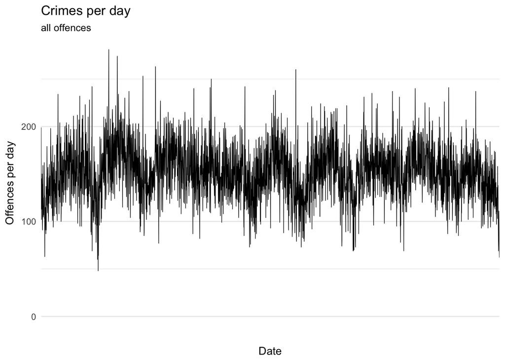

There is seasonal variation in overall crime:

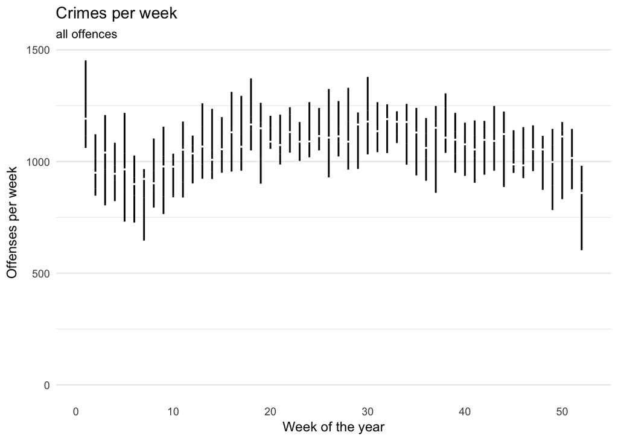

There is variation in the frequency of crime across weekdays:

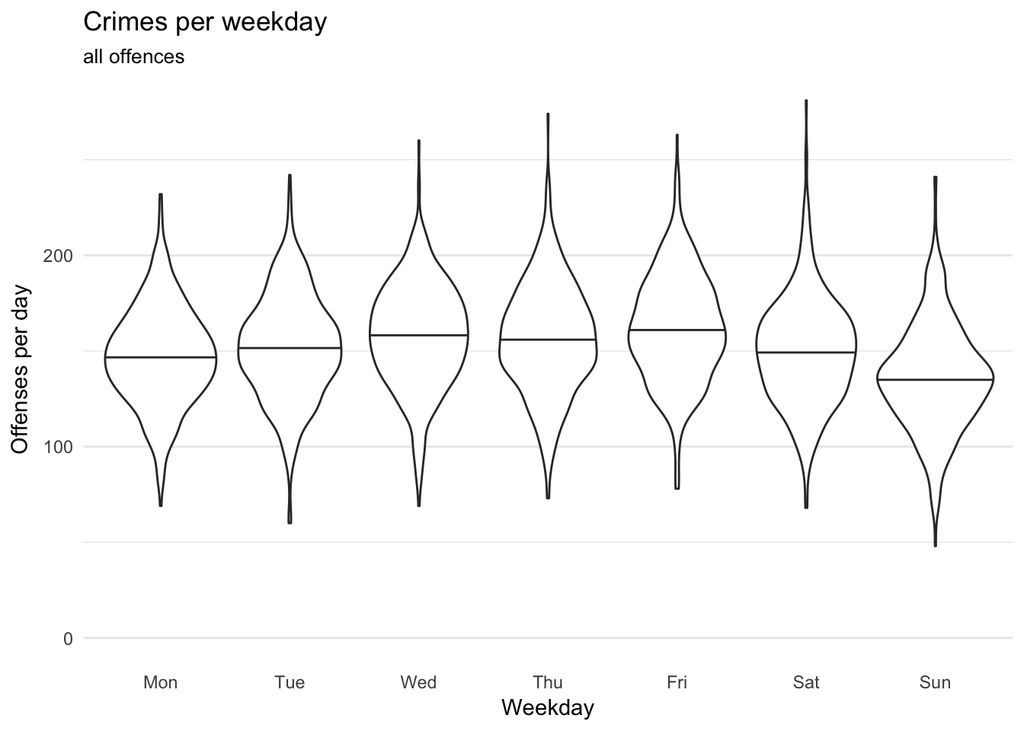

and hours of the day:

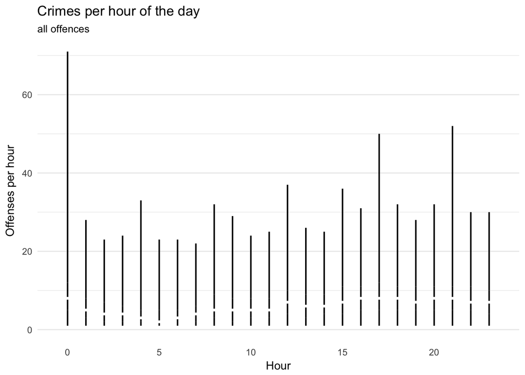

# Spatial distribution

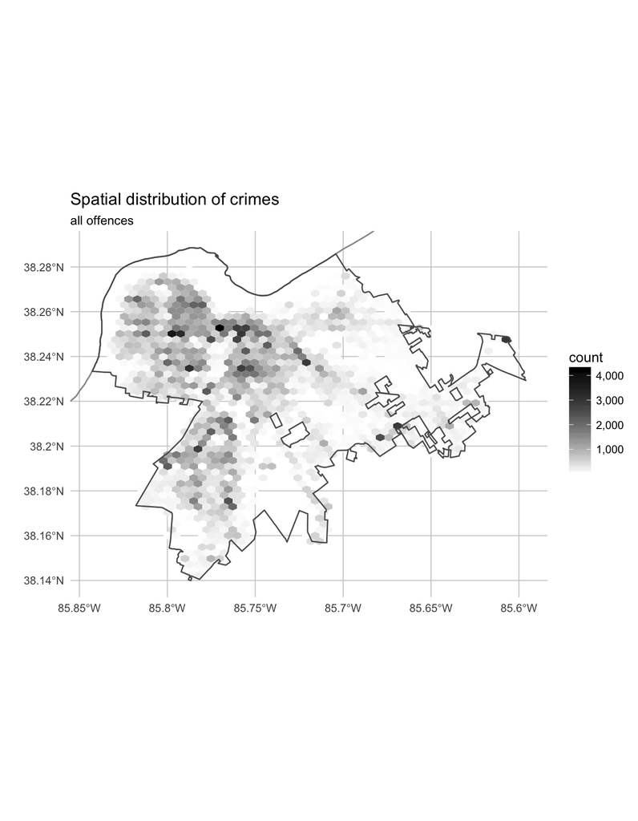

```r
city_outline <- st_read(paste0("../spatial_data/cities/tl_2016_",
                               cities$fips[cities$name == this_city],
                               "_place.shp"), quiet = TRUE) %>%
  filter(NAME == this_city)
city_bbox <- st_bbox(city_outline)

ggplot() +
  geom_sf(data = tigris::states(year = 2016, class = "sf"),
          fill = NA, colour = "#999999") +
  geom_hex(
    mapping = aes(x = longitude, y = latitude),
    data = filter(data, !is.na(latitude) & !is.na(longitude)),
    bins = 50
  ) +
  geom_sf(
    data = city_outline, fill = NA
  ) +
  lims(x = c(city_bbox$xmin, city_bbox$xmax),
       y = c(city_bbox$ymin, city_bbox$ymax)) +
  scale_fill_continuous(low = "#FFFFFF", high = "#000000",
                        label = scales::comma) +
  labs(title = "Spatial distribution of crimes", subtitle = "all offences",
       x = "", y = "") +
  theme_minimal() +
  theme(
    panel.grid.major = element_line(colour = "#CCCCCC")
  )
```

# Crime types

Offenses in the CODE data are split into three categories: crimes against people, property and society. These categories are then split into smaller categories for different offense types.

## Crimes against people

| Group | Type | Cases |
| --- | --- | --- |
| homicide offenses | murder and nonnegligent manslaughter | 461 |
| homicide offenses | negligent manslaughter | 8 |
| kidnapping/abduction | kidnapping/abduction | 964 |
| sex offenses | rape (except statutory rape) | 1,099 |
| sex offenses | sodomy | 586 |
| sex offenses | fondling | 902 |
| assault offenses | aggravated assault | 5,161 |
| assault offenses | simple assault | 29,935 |
| assault offenses | intimidation | 13,475 |
| sex offenses, nonforcible | incest | 13 |

[output cut: 1 more lines]

## Crimes against property

| Group | Type | Cases |
| --- | --- | --- |
| robbery | personal robbery | 27,987 |
| robbery | commercial robbery | 8,631 |
| robbery | other robbery | 812 |
| arson | arson | 30 |
| extortion/blackmail | extortion/blackmail | 14 |
| burglary/breaking & entering | residential burglary/breaking & entering | 109,543 |
| burglary/breaking & entering | non-residential burglary/breaking & ent … | 25,329 |
| larceny/theft offenses | pocket-picking | 430 |
| larceny/theft offenses | purse-snatching | 426 |
| larceny/theft offenses | shoplifting | 13,704 |

[output cut: 17 more lines]

## Crimes against society

| Group | Type | Cases |
| --- | --- | --- |
| drug/narcotic offenses | drug/narcotic violations | 58,802 |
| drug/narcotic offenses | drug equipment violations | 22,416 |
| pornography/obscene material | pornography/obscene material | 62 |
| gambling offenses | operating/promoting/assisting gambling | 25 |
| gambling offenses | gambling equipment violations | 53 |
| prostitution offenses | prostitution | 1,024 |
| prostitution offenses | assisting or promoting prostitution | 169 |
| weapon law violations | weapon law violations | 6,134 |
| curfew/loitering/vagrancy violations | curfew/loitering/vagrancy violations | 33 |
| disorderly conduct | disorderly conduct | 333 |

[output cut: 6 more lines]

## Crime types missing from the data

```r
if (length(missing_types) > 0) {
  cat("Some types of crime are missing from the", this_city, "data:\n\n")
  cat(paste("  *", missing_types), sep = "\n")
}
```

Some types of crime are missing from the Louisville data:

- 11c Sexual Assault With An Object
- 39a Betting/Wagering
- 39d Sports Tampering
- 40c Purchasing Prostitution
- 64a Human Trafficking, Commercial Sex Acts
- 64b Human Trafficking, Involuntary Servitude

```r
other_cats <- data %>%
  filter(str_sub(offense_code, 3, 3) == "U") %>%
  mutate(Type = paste(offense_code, offense_type)) %>%
  group_by(Type) %>%
  summarise(Cases = n()) %>%
  mutate(Cases = format(Cases, big.mark = ","))

if (nrow(other_cats) > 0) {
  cat("Due to limitations in the matching process between crime types in the",
      "original data and the CODE crime categories, some crimes have been",
      "coded to an 'other' category within the relevent higher-level category.",
      "Specifically, crimes have been coded to the following 'other'",
      "categories:", "\n\n")
}
```

Due to limitations in the matching process between crime types in the original data and the CODE crime categories, some crimes have been coded to an ‘other’ category within the relevent higher-level category. Specifically, crimes have been coded to the following ‘other’ categories:

| Type | Cases |
| --- | --- |
| 12U other robbery | 812 |